# Taller 01 - Foundation Models: Comparacion, Decodificacion y Razonamiento

**MMIA 6013 - IA Generativa y Agentes** | Universidad San Francisco de Quito

Semana 1, Sesion 05 | Peso: 25 % de la nota final | Entrega: 2026-09-19

Autor: *(tu nombre)*

## Tarea elegida

Elegí diez problemas de aritmética con respuesta entera para verificar automáticamente los resultados. Agregué tres casos contaminados y comparé cómo cambian las respuestas al modificar el modelo, el prompt y el esfuerzo.

## Indice

| Parte | Contenido | Peso |
| --- | --- | --- |
| 0 | GPT-2 local: distribucion, tres palancas, limite del modelo base | 10 % |
| 1 | Comparacion de 3 modelos: calidad, latencia, costo | 10 % |
| 2.a | Matriz de exposicion de parametros | 8 % |
| 2.b | Barrido temperature x top_p | 12 % |
| 3 | Prompting estructurado: 4 variantes | 15 % |
| 4.a | Barrido de esfuerzo de razonamiento | 15 % |
| 4.b | Casos contaminados | 10 % |
| 5 | Reflexion teorica | 10 % |

[output not shown]

```
10 casos limpios + 3 contaminados
```

|  | id | tipo | pregunta | respuesta |
| --- | --- | --- | --- | --- |
| 0 | c01 | limpio | Un taller compra 17 cajas de 36 tornillos cada... | 311 |
| 1 | c02 | limpio | Una cooperativa recoge 936 huevos. Reserva exa... | 65 |
| 2 | c03 | limpio | Una tienda vende 48 mochilas. El precio de lis... | 2870 |
| 3 | c04 | limpio | Un tanque contiene 1250 litros de agua. Primer... | 820 |
| 4 | c05 | limpio | Una fábrica recibe 23 cajas con 48 piezas cada... | 60 |
| 5 | c06 | limpio | Un museo recauda 2375 pesos por entradas. Vend... | 17 |
| 6 | c07 | limpio | Hay que transportar 1487 kilogramos de materia... | 15 |
| 7 | c08 | limpio | Un almacén tiene 2400 cuadernos. Recibe una en... | 92 |
| 8 | c09 | limpio | Tres máquinas producen, cada una, 17 piezas po... | 369 |
| 9 | c10 | limpio | Cinco personas tenían 300 pesos cada una. Cada... | 84 |
| 10 | c11 | contaminado | Ana tiene 12 manzanas. Su hermano mide 170 cen... | 7 |
| 11 | c12 | contaminado | Un bate y una pelota cuestan 11 dólares en tot... | 1 |
| 12 | c13 | contaminado | En una tienda, 8 de cada 10 clientes que compr... | 30 |

# Parte 0 - El modelo base y la distribucion (10 %)

```
Modelo: openai-community/gpt2
Revisión: 607a30d783dfa663caf39e06633721c8d4cfcd7e
Parámetros: 124439808
Versiones: 2.14.0+cpu 5.17.0
Dispositivo: CPU; hilos: 4
Semilla base: 123
La latencia mide generate(), sin carga del modelo ni tokenización.
```

## 0.a — La distribución del siguiente token (4 %)

En el dominio de números y cálculo uso `As easy as one, two,` como frase hecha relativamente predecible y `To calculate the total, we need to` como contexto abierto. Los prefijos están en inglés, la lengua predominante del [modelo base](https://huggingface.co/openai-community/gpt2). La certeza se comprueba con la probabilidad máxima y la entropía; no se supone.

Se hace un forward por prefijo y se reutilizan sus logits para todas las temperaturas. La softmax, la entropía y el núcleo se calculan sobre **todo el vocabulario**, aunque la primera figura solo muestre los 15 primeros tokens.

```
Logits conservados por prefijo: 50257
```

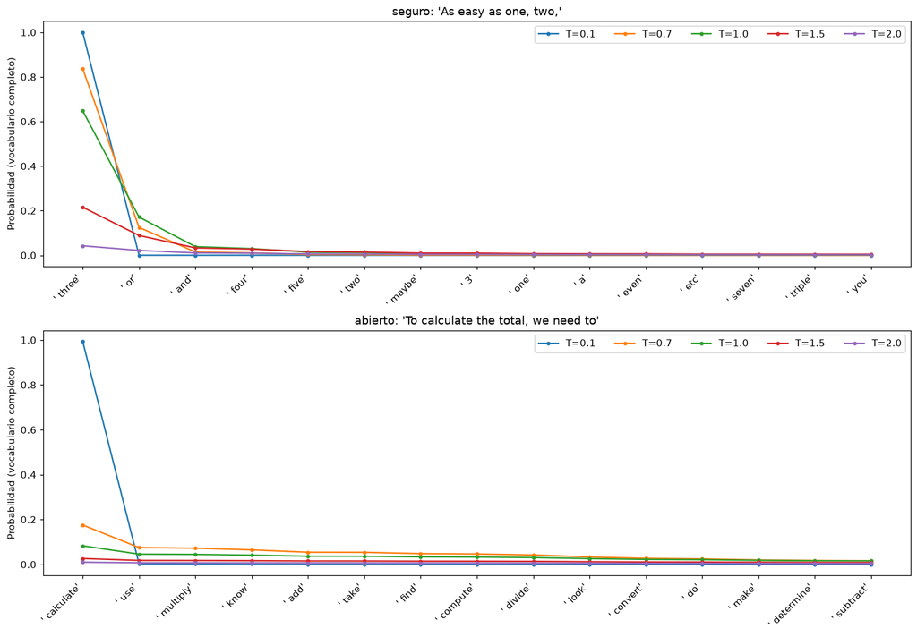

```
Entropía en bits y núcleo mínimo comprobados.
```

|  | prefijo_id | temperature | entropia_bits | nucleo_09 | probabilidad_maxima |
| --- | --- | --- | --- | --- | --- |
| 0 | seguro | 0.1 | 0.000034 | 1 | 0.999998 |
| 1 | seguro | 0.7 | 0.885789 | 2 | 0.836486 |
| 2 | seguro | 1.0 | 2.322776 | 5 | 0.648169 |
| 3 | seguro | 1.5 | 9.068163 | 7659 | 0.215500 |
| 4 | seguro | 2.0 | 13.228978 | 20702 | 0.042561 |
| 5 | abierto | 0.1 | 0.068400 | 1 | 0.993693 |
| 6 | abierto | 0.7 | 5.128708 | 40 | 0.175539 |
| 7 | abierto | 1.0 | 7.100098 | 241 | 0.082935 |
| 8 | abierto | 1.5 | 9.894403 | 1735 | 0.026241 |
| 9 | abierto | 2.0 | 11.816834 | 6464 | 0.009824 |

Al reducir T, la masa se concentra en los tokens con logits más altos y disminuye la entropía. Al aumentar T, se reparte más masa entre alternativas y crece el conjunto necesario para acumular el 90 %. A T=1, el prefijo seguro tiene 2.323 bits y un núcleo de 5 tokens, mientras que el abierto tiene 7.100 bits y 241 tokens. La probabilidad del candidato principal es 64.8% frente a 8.3%, por lo que top_p=0.9 fija una masa, pero no un número constante de tokens.

**Entregable 0.a**

Al bajar la temperatura, observé más probabilidad concentrada en los primeros tokens. Al subirla, aumentaron la entropía y las alternativas. Con temperatura 1, el núcleo del 90 % incluyó cinco tokens en el prefijo seguro y 241 en el abierto.

## 0.b — Las tres palancas sobre esa misma distribución (4 %)

Uso `model.generate(...)`, modo evaluación y semilla registrada por corrida. Para aislar cada palanca desactivo los otros filtros: `top_k=0`, `top_p=1`, sin penalización de repetición y con un solo beam. El aviso de Transformers al enviar temperatura en modo greedy se conserva: ese parámetro se ignora. Véase la [documentación de generación](https://huggingface.co/docs/transformers/main_classes/text_generation).

Cada generación se añade a `datos/resultados.csv`, con `parte=0` y costo cero. `datos/parte0_generaciones.jsonl` conserva además el prompt, los IDs, la semilla, la revisión del modelo, la fecha y los parámetros exactos. En esta parte `acierto` queda vacío porque no se evalúa exactitud.

```
[transformers] The following generation flags are not valid and may be ignored: ['temperature', 'top_k']. Set `TRANSFORMERS_VERBOSITY=info` for more details.
```

```
--- do_sample=False, temperature=0.2 ---
 calculate the total of all the items in the list.

$item = array( 'total' => $item, 'total' => $item, 'total' => $item, '
IDs: [15284, 262, 2472, 286, 477, 262, 3709, 287, 262, 1351, 13, 198, 198, 3, 9186, 796, 7177, 7, 705, 23350, 6, 5218, 720, 9186, 11, 705, 23350, 6, 5218, 720, 9186, 11, 705, 23350, 6, 5218, 720, 9186, 11, 705]
```

```
--- do_sample=False, temperature=1.5 ---
 calculate the total of all the items in the list.

$item = array( 'total' => $item, 'total' => $item, 'total' => $item, '
IDs: [15284, 262, 2472, 286, 477, 262, 3709, 287, 262, 1351, 13, 198, 198, 3, 9186, 796, 7177, 7, 705, 23350, 6, 5218, 720, 9186, 11, 705, 23350, 6, 5218, 720, 9186, 11, 705, 23350, 6, 5218, 720, 9186, 11, 705]

IDs idénticos: True
```

Greedy elige el argmax en cada paso. La temperatura enviada no se aplica cuando `do_sample=False`; por eso ambas secuencias coinciden. Además, dividir logits por una temperatura positiva conserva su orden.

```
--- Corrida 0, semilla=123 ---
 calculate the total of all the items in the list.

$item = array( 'total' => $item, 'total' => $item, 'total' => $item, '
IDs: [15284, 262, 2472, 286, 477, 262, 3709, 287, 262, 1351, 13, 198, 198, 3, 9186, 796, 7177, 7, 705, 23350, 6, 5218, 720, 9186, 11, 705, 23350, 6, 5218, 720, 9186, 11, 705, 23350, 6, 5218, 720, 9186, 11, 705]
Soporte tras el filtro, en cada paso: [1, 1, 1, 1, 1, 1, 1, 1, 1, 1, 1, 1, 1, 1, 1, 1, 1, 1, 1, 1, 1, 1, 1, 1, 1, 1, 1, 1, 1, 1, 1, 1, 1, 1, 1, 1, 1, 1, 1, 1]
```

```
--- Corrida 1, semilla=124 ---
 calculate the total of all the items in the list.

$item = array( 'total' => $item, 'total' => $item, 'total' => $item, '
IDs: [15284, 262, 2472, 286, 477, 262, 3709, 287, 262, 1351, 13, 198, 198, 3, 9186, 796, 7177, 7, 705, 23350, 6, 5218, 720, 9186, 11, 705, 23350, 6, 5218, 720, 9186, 11, 705, 23350, 6, 5218, 720, 9186, 11, 705]
Soporte tras el filtro, en cada paso: [1, 1, 1, 1, 1, 1, 1, 1, 1, 1, 1, 1, 1, 1, 1, 1, 1, 1, 1, 1, 1, 1, 1, 1, 1, 1, 1, 1, 1, 1, 1, 1, 1, 1, 1, 1, 1, 1, 1, 1]
```

```
--- Corrida 2, semilla=125 ---
 calculate the total of all the items in the list.

$item = array( 'total' => $item, 'total' => $item, 'total' => $item, '
IDs: [15284, 262, 2472, 286, 477, 262, 3709, 287, 262, 1351, 13, 198, 198, 3, 9186, 796, 7177, 7, 705, 23350, 6, 5218, 720, 9186, 11, 705, 23350, 6, 5218, 720, 9186, 11, 705, 23350, 6, 5218, 720, 9186, 11, 705]
Soporte tras el filtro, en cada paso: [1, 1, 1, 1, 1, 1, 1, 1, 1, 1, 1, 1, 1, 1, 1, 1, 1, 1, 1, 1, 1, 1, 1, 1, 1, 1, 1, 1, 1, 1, 1, 1, 1, 1, 1, 1, 1, 1, 1, 1]
```

```
--- Corrida 3, semilla=126 ---
 calculate the total of all the items in the list.

$item = array( 'total' => $item, 'total' => $item, 'total' => $item, '
IDs: [15284, 262, 2472, 286, 477, 262, 3709, 287, 262, 1351, 13, 198, 198, 3, 9186, 796, 7177, 7, 705, 23350, 6, 5218, 720, 9186, 11, 705, 23350, 6, 5218, 720, 9186, 11, 705, 23350, 6, 5218, 720, 9186, 11, 705]
Soporte tras el filtro, en cada paso: [1, 1, 1, 1, 1, 1, 1, 1, 1, 1, 1, 1, 1, 1, 1, 1, 1, 1, 1, 1, 1, 1, 1, 1, 1, 1, 1, 1, 1, 1, 1, 1, 1, 1, 1, 1, 1, 1, 1, 1]
```

```
--- Corrida 4, semilla=127 ---
 calculate the total of all the items in the list.

$item = array( 'total' => $item, 'total' => $item, 'total' => $item, '
IDs: [15284, 262, 2472, 286, 477, 262, 3709, 287, 262, 1351, 13, 198, 198, 3, 9186, 796, 7177, 7, 705, 23350, 6, 5218, 720, 9186, 11, 705, 23350, 6, 5218, 720, 9186, 11, 705, 23350, 6, 5218, 720, 9186, 11, 705]
Soporte tras el filtro, en cada paso: [1, 1, 1, 1, 1, 1, 1, 1, 1, 1, 1, 1, 1, 1, 1, 1, 1, 1, 1, 1, 1, 1, 1, 1, 1, 1, 1, 1, 1, 1, 1, 1, 1, 1, 1, 1, 1, 1, 1, 1]
```

Las cinco semillas producen los mismos IDs que greedy. Se comprueba también la distribución filtrada: en cada paso queda un único logit finito, cuya probabilidad tras softmax es 1. No se deduce el resultado únicamente de repetir la misma semilla.

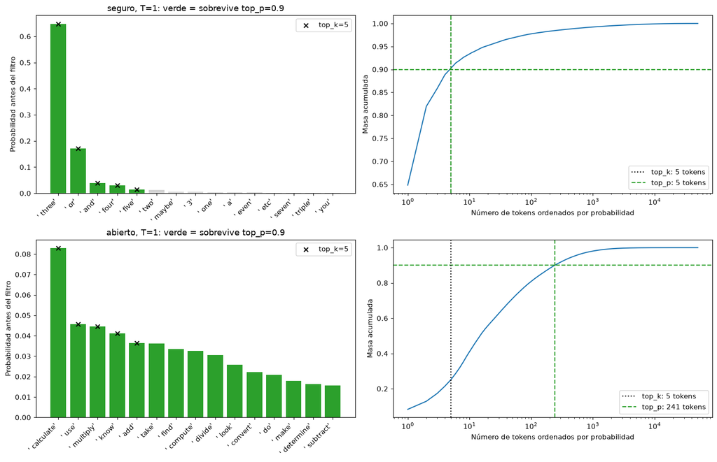

|  | prefijo | top_k | nucleo_09 | masa_top_k | masa_top_p | conjuntos_iguales |
| --- | --- | --- | --- | --- | --- | --- |
| 0 | seguro | 5 | 5 | 0.902416 | 0.902416 | True |
| 1 | abierto | 5 | 241 | 0.250967 | 0.900243 | False |

A T=1, las cruces identifican los cinco tokens de `top_k=5` y el verde los que sobreviven a `top_p=0.9`. La curva acumulada muestra también los tokens que quedan fuera de los 15 visibles. Se compararon ambos conjuntos con los filtros reales de Transformers. Top-k fija el tamaño del conjunto en estos logits sin empates; top-p fija la masa mínima que debe conservarse.

```
[transformers] The following generation flags are not valid and may be ignored: ['top_k']. Set `TRANSFORMERS_VERBOSITY=info` for more details.
```

```
Prefijo: To calculate the total, we need to
Continuación cruda, 100 tokens:
 calculate the total of all the items in the list.

$item = array( 'total' => $item, 'total' => $item, 'total' => $item, 'total' => $item, 'total' => $item, 'total' => $item, 'total' => $item, 'total' => $item, 'total' => $item, 'total' => $item, 'total' => $item, 'total' => $
IDs: [15284, 262, 2472, 286, 477, 262, 3709, 287, 262, 1351, 13, 198, 198, 3, 9186, 796, 7177, 7, 705, 23350, 6, 5218, 720, 9186, 11, 705, 23350, 6, 5218, 720, 9186, 11, 705, 23350, 6, 5218, 720, 9186, 11, 705, 23350, 6, 5218, 720, 9186, 11, 705, 23350, 6, 5218, 720, 9186, 11, 705, 23350, 6, 5218, 7…
Ventanas de 4 tokens repetidas (apariciones extra): 72 de 97
```

Se fija también `min_new_tokens=100` para conservar exactamente cien tokens nuevos; esto impide terminar antes con EOS. No se aplican penalizaciones para disimular repeticiones. La repetición observada se analiza como degeneración por decodificación, relacionada con [Holtzman et al. (2020)](https://arxiv.org/abs/1904.09751); una corrida no implica que greedy se repita en todos los contextos.

**Entregable 0.b.** Arriba se conservan las dos salidas del interruptor, las cinco corridas de `top_k=1` con sus IDs y soportes, la figura de cortes y la continuación de cien tokens sin editar. El conteo de cuatrigramas repetidos complementa la observación del texto; no evalúa su corrección.

## 0.c — El límite del modelo base (2 %)

Uso la instrucción zero-shot compartida con `construir_prompt()` en `src/clientes.py`. Incluye el caso `c01`, pero aquí solo observo cómo continúa el texto: no calculo exactitud sobre los diez casos.

```
INSTRUCCIÓN EXACTA:
Resuelve el siguiente problema. Responde únicamente con un número entero, sin explicación ni unidades.

Un taller compra 17 cajas de 36 tornillos cada una. Usa 7 tornillos por cada una de 43 sillas. ¿Cuántos tornillos le sobran?

SALIDA CRUDA:


Una cada una de 43 sillas. ¿Cuántos tornillos le sobran?

Una cada una de 43 sillas. ¿Cuántos tornillos le sobran?

Una cada una de 43 sillas. ¿Cuántos tornillos le sobran?

Una cada una de 43 sillas. ¿Cuántos
```

|  | plantilla | corrida | temperature | top_k | tokens_entrada | tokens_salida | latencia_s | costo_usd |
| --- | --- | --- | --- | --- | --- | --- | --- | --- |
| 841 | 0b_interruptor | 0 | 0.2 | 0.0 | 8.0 | 40.0 | 0.641728 | 0.0 |
| 842 | 0b_interruptor | 0 | 1.5 | 0.0 | 8.0 | 40.0 | 0.592625 | 0.0 |
| 843 | 0b_top_k_1 | 0 | 1.0 | 1.0 | 8.0 | 40.0 | 0.689752 | 0.0 |
| 844 | 0b_top_k_1 | 1 | 1.0 | 1.0 | 8.0 | 40.0 | 0.671519 | 0.0 |
| 845 | 0b_top_k_1 | 2 | 1.0 | 1.0 | 8.0 | 40.0 | 0.745217 | 0.0 |
| 846 | 0b_top_k_1 | 3 | 1.0 | 1.0 | 8.0 | 40.0 | 0.762167 | 0.0 |
| 847 | 0b_top_k_1 | 4 | 1.0 | 1.0 | 8.0 | 40.0 | 0.628623 | 0.0 |
| 848 | 0b_degeneracion | 0 | 1.0 | 0.0 | 8.0 | 100.0 | 1.816359 | 0.0 |
| 849 | zero_shot | 0 | 1.0 | 0.0 | 87.0 | 100.0 | 1.729502 | 0.0 |

**Entregable 0.c**

GPT-2 repitió partes del problema en lugar de responder con un número. Su entrenamiento está orientado a continuar texto. El ajuste con instrucciones puede mejorar ese comportamiento, aunque no garantiza respuestas correctas. También considero que el problema estaba en español y GPT-2 se entrenó principalmente en inglés.

# Parte 1 - Comparacion de modelos (10 %)

| Ranura | Fila | Modelo | USD/M entrada | USD/M salida | Verificado |
| --- | --- | --- | --- | --- | --- |
| propietario grande / razonamiento | `openai_razonamiento` | `gpt-5.6-luna` | 0,20 | 1,20 | 2026-09-18 |
| propietario economico | `propietario_economico` | `gpt-4o-mini` | 0,15 | 0,60 | 2026-08-26 |
| open-weight local | `open_weight_pequeno` | `qwen3:1.7b` | 0 | 0 | - |

```
parte
0      36
1      30
2a    108
2b    600
3      40
4a     30
4b      6
dtype: int64
```

|  | modelo | exactitud | latencia_s | tokens_in | tokens_out | costo_usd | precio_verificado |
| --- | --- | --- | --- | --- | --- | --- | --- |
| 0 | gpt-4o-mini | 0.0 | 1.90635 | 793.0 | 12.0 | 0.00013 | 2026-08-26 |
| 1 | gpt-5.6-luna | 1.0 | 1.13001 | 783.0 | 405.0 | 0.00064 | 2026-09-18 |
| 2 | qwen3:1.7b | 0.9 | 10.67651 | 1011.0 | 7424.0 | 0.00000 | local (cero real) |

**Conclusión Parte 1**

Elegiría gpt-5.6-luna: acertó los diez casos y costó aproximadamente 0,00064 dólares en total. Qwen acertó nueve sin cobro de API, pero tardó más y necesitó recursos locales. Ampliaría las pruebas antes de usar cualquiera en producción.

Confirmo que los precios de la tabla se leyeron de la tabla semestral del enunciado, con la fecha de cada fila, y no de memoria.

# Parte 2 - Decodificacion: que expone la API y que hace el dial (20 %)

## 2.a - Verificar la matriz de exposicion (8 %)

| Estado | Como se comprueba |
| --- | --- |
| Aceptado y actua | responde 200 **y** dos valores distintos producen distribuciones de salida distintas en *n* corridas |
| Aceptado y no actua | responde 200 pero la salida **no cambia** entre valores extremos |
| Rechazado | devuelve error; se transcribe el codigo y el mensaje **literal** |

|  | modelo | parametro | declarado | observado | evidencia | fecha |
| --- | --- | --- | --- | --- | --- | --- |
| 0 | gpt-4o-mini | temperature | si | aceptado y actua | temperature=0: 0% de casos con corridas distintas; temperature=1.5: 100% de casos con corridas distintas | 2026-09-20 |
| 1 | gpt-4o-mini | top_p | si | aceptado y actua | top_p=0.1: 33% de casos con corridas distintas; top_p=1: 67% de casos con corridas distintas | 2026-09-20 |
| 2 | gpt-4o-mini | top_k | no | rechazado | 12/12 llamadas con error | 2026-09-20 |
| 3 | gpt-5.6-luna | temperature | no_en_esta_fila | rechazado | 12/12 llamadas con error | 2026-09-20 |
| 4 | gpt-5.6-luna | top_p | no_en_esta_fila | rechazado | 6/12 llamadas con error | 2026-09-20 |
| 5 | gpt-5.6-luna | top_k | no | rechazado | 12/12 llamadas con error | 2026-09-20 |
| 6 | qwen3:1.7b | temperature | si | aceptado y actua | temperature=0: 33% de casos con corridas distintas; temperature=1.5: 100% de casos con corridas distintas | 2026-09-20 |
| 7 | qwen3:1.7b | top_p | si | aceptado y actua | top_p=0.1: 33% de casos con corridas distintas; top_p=1: 100% de casos con corridas distintas | 2026-09-20 |
| 8 | qwen3:1.7b | top_k | si | aceptado y actua | top_k=1: 33% de casos con corridas distintas; top_k=40: 100% de casos con corridas distintas | 2026-09-20 |

```
[gpt-4o-mini] top_k (2026-09-20)
    TypeError: Completions.create() got an unexpected keyword argument 'top_k'

[gpt-5.6-luna] temperature (2026-09-20)
    400: Error code: 400 - {'error': {'message': "Unsupported value: 'temperature' does not support 0.0 with this model. Only the default (1) value is supported.", 'type': 'invalid_request_error', 'param': 'temperature', 'code':

[gpt-5.6-luna] top_p (2026-09-20)
    400: Error code: 400 - {'error': {'message': "Unsupported parameter: 'top_p' is not supported with this model.", 'type': 'invalid_request_error', 'param': 'top_p', 'code': 'unsupported_parameter'}}

[gpt-5.6-luna] top_k (2026-09-20)
    TypeError: Completions.create() got an unexpected keyword argument 'top_k'
```

**Hallazgos y discrepancias 2.a** (prueba: 2026-09-20)

En gpt-4o-mini, temperatura y top-p mostraron cambios entre corridas. Top-k falló en el SDK, antes de llegar al servidor. Luna rechazó las temperaturas probadas y aceptó top_p=1, pero rechazó 0.1. En Ollama observé contenido en thinking sin pedirlo, contrario al valor predeterminado indicado en la tabla.

## 2.b - Barrido de temperature y top-p (12 %)

Sobre un modelo cuya matriz de 2.a diga **aceptado y actua**:

- `temperature` in {0, 0.3, 0.7, 1.0, 1.5} x `top_p` in {0.5, 0.9, 1.0}
- **5 corridas por celda** sobre los mismos 10 casos = **750 llamadas**

```
750 llamadas estimadas -> $0.383 USD (precio verificado 2026-08-26)
Corrido con 3 corridas por celda en vez de 5 por limite de tiempo: 450 llamadas.
```

|  | temperature | top_p | exactitud | tokens_out | estabilidad |
| --- | --- | --- | --- | --- | --- |
| 0 | 0.0 | 0.5 | 0.000000 | 1.200 | 1.000 |
| 1 | 0.0 | 0.9 | 0.000000 | 1.200 | 0.967 |
| 2 | 0.0 | 1.0 | 0.000000 | 1.200 | 1.000 |
| 3 | 0.3 | 0.5 | 0.000000 | 1.400 | 0.767 |
| 4 | 0.3 | 0.9 | 0.000000 | 1.200 | 0.833 |
| 5 | 0.3 | 1.0 | 0.000000 | 1.267 | 0.767 |
| 6 | 0.7 | 0.5 | 0.000000 | 1.400 | 0.700 |
| 7 | 0.7 | 0.9 | 0.033333 | 1.167 | 0.567 |
| 8 | 0.7 | 1.0 | 0.000000 | 1.233 | 0.700 |
| 9 | 1.0 | 0.5 | 0.000000 | 1.267 | 0.633 |
| 10 | 1.0 | 0.9 | 0.000000 | 1.233 | 0.500 |
| 11 | 1.0 | 1.0 | 0.000000 | 1.367 | 0.567 |
| 12 | 1.5 | 0.5 | 0.000000 | 1.333 | 0.700 |
| 13 | 1.5 | 0.9 | 0.033333 | 1.400 | 0.533 |
| 14 | 1.5 | 1.0 | 0.033333 | 1284.133 | 0.367 |

|  | top_k | modelo | temperature | exactitud | tokens_out | estabilidad_salida | casos_identicos_x5 |
| --- | --- | --- | --- | --- | --- | --- | --- |
| 0 | 1.0 | qwen3:1.7b | 1.0 | 0.92 | 1080.32 | 0.96 | 8 |
| 1 | 5.0 | qwen3:1.7b | 1.0 | 0.96 | 947.78 | 0.88 | 7 |
| 2 | 40.0 | qwen3:1.7b | 1.0 | 0.98 | 931.12 | 0.86 | 7 |

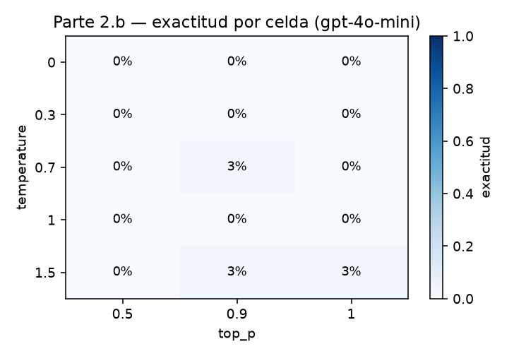

**Conclusión 2.b**

Encontré doce configuraciones con 0 % de exactitud y tres con 3,33 %. Ninguna fue suficiente para esta tarea. Usaría T=0 y top_p=1 como punto de partida por su estabilidad, pero tendría que mejorar el prompt o cambiar de modelo. Para titulares probaría T=1 y top_p=0.9, evaluándolos por separado. Al bajar la temperatura, la distribución concentra más probabilidad en los tokens favorecidos; al subirla, reparte más masa entre alternativas. En local, top_k=1 dio la misma salida en ocho de diez casos en cinco corridas secuenciales, no en los diez. Ejecuté tres repeticiones por caso y configuración, no las cinco solicitadas.

# Parte 3 - Prompting estructurado (15 %)

```
=== zero_shot | caso c01 | acierto=False ===
245

=== few_shot | caso c01 | acierto=False ===
81

=== cot | caso c01 | acierto=True ===
Para resolver este problema, primero vamos a determinar cuántos tornillos hay en las cajas y luego cuántos tornillos se usan para fabricar las sillas.

1. **Calcular el total de tornillos comprados:**
   - El taller compra 17 cajas.
   - Cada caja contiene 36 tornillos.
   - Por lo tanto, el total de tornillos comprados es:
     \[
     17 \text{ cajas} \times 36 \text{ tornillos/caja} = 612 \text{ tornillos}
     \]

2. **Calcular cuántos tornillos se usan para las sillas:**
   - Se usan 7 tornillos para cada silla.
   - El taller necesita hacer 43 sillas.
   - Por lo tanto, el total de torni

=== structured | caso c01 | acierto=False ===
{"respuesta": 71}
```

```
structured: 10/10 salidas parsearon como JSON; 0/10 correctas
```

|  | plantilla | exactitud | tokens_in | tokens_out | costo_usd |
| --- | --- | --- | --- | --- | --- |
| 0 | zero_shot | 0.1 | 793.0 | 11.0 | 0.00013 |
| 1 | few_shot | 0.0 | 1842.0 | 11.0 | 0.00028 |
| 2 | cot | 1.0 | 933.0 | 3160.0 | 0.00204 |
| 3 | structured | 0.0 | 883.0 | 61.0 | 0.00017 |

**Conclusión Parte 3**

Zero-shot acertó un caso, few-shot ninguno y CoT los diez. CoT aumentó los tokens de salida de 11 a 3160 y el costo aproximado de 0,00013 a 0,00204 dólares. La variante estructurada produjo diez JSON válidos, pero ninguna respuesta correcta; usé el modo JSON del proveedor, sin esquema estricto. Elegiría CoT para estos ejercicios, few-shot para mostrar criterios mediante ejemplos y salida estructurada cuando otro programa necesite leer la respuesta.

# Parte 4 - Modelos de razonamiento y niveles de esfuerzo (25 %)

Modelo: `gpt-5.6-luna` (fila `openai_razonamiento`)

- dial: `reasoning.effort` (Responses API) / `reasoning_effort` (Chat Completions)
- valores: `none, low, medium, high, xhigh, max` -- por defecto `medium`
- contador: `usage.output_tokens_details.reasoning_tokens`

## 4.a - Barrido de esfuerzo (15 %)

| Columna | De donde sale |
| --- | --- |
| exactitud sobre los 10 casos | tu verificador |
| tokens de razonamiento | `output_tokens_details.reasoning_tokens` |
| tokens de salida visibles | total de salida **menos** los de razonamiento |
| latencia | el mismo cronometro de la Parte 1 |
| costo USD | tokens de salida **totales, razonamiento incluido**, al precio de la fila |

Se corrió `low` completo primero: 287 tokens de razonamiento en 10 casos, muy por debajo del supuesto de 1 500 del enunciado. La cuenta se rehizo con esa cifra antes de lanzar `medium` y `high`.

|  | esfuerzo | exactitud | tokens_razonamiento | tokens_salida | latencia_s | costo_usd | tokens_visibles |
| --- | --- | --- | --- | --- | --- | --- | --- |
| 0 | low | 1.0 | 287.0 | 388.0 | 1.23172 | 0.00062 | 101.0 |
| 1 | medium | 1.0 | 288.0 | 389.0 | 0.95785 | 0.00062 | 101.0 |
| 2 | high | 1.0 | 375.0 | 476.0 | 1.01251 | 0.00073 | 101.0 |

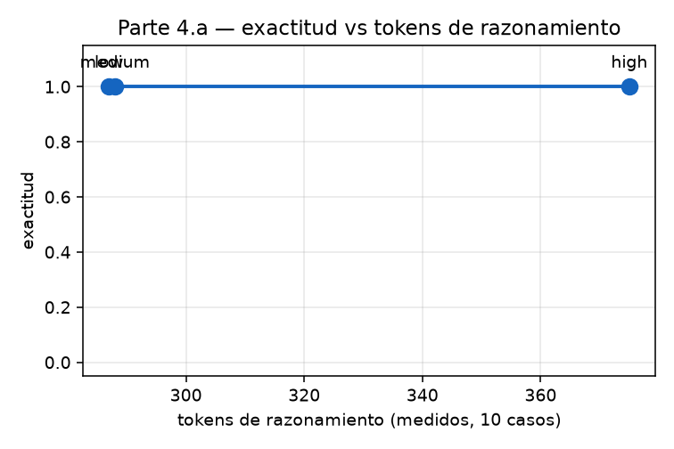

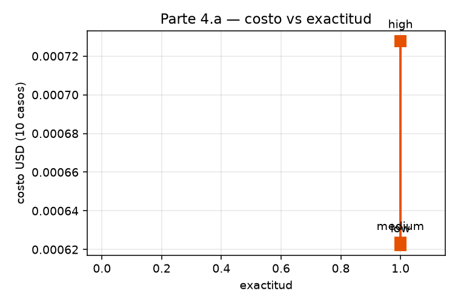

**Conclusión 4.a**

Los tres niveles acertaron los diez casos. Low consumió 287 tokens de razonamiento; medium, 288; y high, 375. De medium a high pagué 0,0001044 dólares adicionales sin mejorar la exactitud. Elegiría low para este conjunto. La similitud entre low y medium no demuestra que el parámetro se ignore; necesitaría más casos y repeticiones.

## 4.b - El caso donde pensar mas hace dano (10 %)

| id | Modo de fallo (Gema et al., 2025) | Respuesta |
| --- | --- | --- |
| c11 | distraccion por lo irrelevante | 7 |
| c12 | sobreajuste al marco del problema | 1 |
| c13 | adopcion de correlaciones espurias | 30 |

|  | esfuerzo | caso_id | acierto | tokens_razonamiento |
| --- | --- | --- | --- | --- |
| 0 | high | c11 | 1.0 | 0.0 |
| 1 | high | c12 | 1.0 | 24.0 |
| 2 | high | c13 | 1.0 | 26.0 |
| 3 | low | c11 | 1.0 | 0.0 |
| 4 | low | c12 | 1.0 | 0.0 |
| 5 | low | c13 | 1.0 | 21.0 |

**Análisis 4.b**

No observé empeoramiento: ambos niveles acertaron los tres casos. No reproduje los fallos descritos por Gema et al., pero eso no contradice su estudio. Tres casos no permiten establecer una regla general.

# Parte 5 - Reflexión teórica (10 %)

### 1. Explica intuitivamente qué hace el mecanismo de atención en un transformer. ¿Por qué es importante el concepto de *query, key, value*?

Entiendo la atención como una forma de combinar información relevante del contexto. La query representa lo que una posición busca, las keys permiten comparar y los values aportan el contenido. En generación causal, el modelo no puede atender a tokens futuros.

### 2. ¿Cuál es la diferencia entre un modelo base y un modelo alineado? ¿Por qué un modelo base no es directamente útil para las aplicaciones de este curso?

Salida cruda de 0.c ante la instrucción de la tarea. GPT-2 entró en bucle y repitió este fragmento hasta el límite de tokens; se muestran las tres primeras repeticiones tal como salieron, sin editar:

```
Una cada una de 43 sillas. ¿Cuántos tornillos le sobran?

Una cada una de 43 sillas. ¿Cuántos tornillos le sobran?

Una cada una de 43 sillas. ¿Cuántos tornillos le sobran?
```

En mi prueba, GPT-2 continuó el enunciado sin resolverlo. El ajuste con instrucciones y preferencias busca mejorar la respuesta a peticiones. Para estas aplicaciones necesito seguir instrucciones y respetar formatos, pero también verificar el contenido.

### 3. En la Parte 3, la variante con Chain-of-Thought probablemente usó más tokens que la zero-shot. ¿Cuándo vale la pena pagar ese costo y cuándo no?

Pagaría CoT en estos ejercicios porque pasó de uno a diez aciertos. Para extraer un dato explícito, primero probaría una instrucción corta. Decidiría según la mejora de exactitud, el costo y la latencia medidos.

### 4. En tu matriz de la Parte 2.a hay al menos una celda «rechazado». ¿Qué gana un proveedor al retirar un parámetro de muestreo de su API, y qué pierde quien lo usaba?

Considero que retirar un parámetro puede simplificar el servicio y limitar configuraciones poco evaluadas. Quien lo usa pierde control sobre el muestreo. El esfuerzo ofrece otro ajuste, pero no sustituye directamente a la temperatura.

### 5. Los tokens de razonamiento de la Parte 4 se facturan y casi nunca se devuelven en crudo. Si tu modelo te mostrara la traza completa, ¿sería eso una explicación de cómo llegó a la respuesta?

No asumiría que una explicación convincente refleja cómo se obtuvo la respuesta. Lanham et al. encontraron que la influencia de la cadena cambia según la tarea y el modelo. Para auditar, combinaría las trazas con casos verificables y pruebas controladas.

```
filas: 850
parte
0      36
1      30
2a    108
2b    600
3      40
4a     30
4b      6
dtype: int64
OK: ninguna credencial en el CSV
```